# Project Python Foundations: FoodHub Data Analysis

### **Question 13:** The company wants to provide a promotional offer in the advertisement of the restaurants. The condition to get the offer is that the restaurants must have a rating count of more than 50 and the average rating should be greater than 4. Find the restaurants fulfilling the criteria to get the promotional offer. [3 marks]

```python
# Write the code here
newdf = df.loc[df['rating'] > 4, 'restaurant_name'].value_counts()
newdf.head()
```

| restaurant_name | count |
| --- | --- |
| Shake Shack | 60 |
| The Meatball Shop | 53 |
| Blue Ribbon Fried Chicken | 32 |
| Blue Ribbon Sushi | 32 |
| RedFarm Broadway | 18 |

**dtype:** int64

### **Question 14:** The company charges the restaurant 25% on the orders having cost greater than 20 dollars and 15% on the orders having cost greater than 5 dollars. Find the net revenue generated by the company across all orders. [3 marks]

```python
# Write the code here
def revenue(co):
  if co > 20:
    return co * 0.25

  elif co > 5:
    return co * 0.15
  else:
    return

df['revenue_per_order'] = df['cost_of_the_order'].apply(revenue)
df.head()
```

|  | order_id | customer_id | restaurant_name | cuisine_type | cost_of_the_order | day_of_the_week | rating | food_preparation_time | delivery_time | total_time | revenue_per_order |
| --- | --- | --- | --- | --- | --- | --- | --- | --- | --- | --- | --- |
| 0 | 1477147 | 337525 | Hangawi | Korean | 30.75 | Weekend | NaN | 25 | 20 | 45 | 7.6875 |
| 1 | 1477685 | 358141 | Blue Ribbon Sushi Izakaya | Japanese | 12.08 | Weekend | NaN | 25 | 23 | 48 | 1.8120 |
| 2 | 1477070 | 66393 | Cafe Habana | Mexican | 12.23 | Weekday | 5.0 | 23 | 28 | 51 | 1.8345 |
| 3 | 1477334 | 106968 | Blue Ribbon Fried Chicken | American | 29.20 | Weekend | 3.0 | 25 | 15 | 40 | 7.3000 |
| 4 | 1478249 | 76942 | Dirty Bird to Go | American | 11.59 | Weekday | 4.0 | 25 | 24 | 49 | 1.7385 |

```python
print('Total Revenue generated is', df['revenue_per_order'].sum())
```

```
Total Revenue generated is 6166.303
```

### **Question 15:** The company wants to analyze the total time required to deliver the food. What percentage of orders take more than 60 minutes to get delivered from the time the order is placed? (The food has to be prepared and then delivered.) [2 marks]

```python
# Write the code here
print(round(df.loc[df['total_time'] > 60].shape[0] / df.shape[0] * 100, 3), '% orders took more than 60 minutes to get delivered')
```

```
10.537 % orders took more than 60 minutes to get delivered
```

### **Question 16:** The company wants to analyze the delivery time of the orders on weekdays and weekends. How does the mean delivery time vary during weekdays and weekends? [2 marks]

```python
# Write the code here
df.groupby('day_of_the_week')['delivery_time'].mean().round(3)
```

| day_of_the_week | delivery_time |
| --- | --- |
| Weekday | 28.34 |
| Weekend | 22.47 |

**dtype:** float64

#### Observations:

- Weekdend deliveries are quicker by 5.87 than to Weekday deleviries

### Conclusion and Recommendations

### **Question 17:** What are your conclusions from the analysis? What recommendations would you like to share to help improve the business? (You can use cuisine type and feedback ratings to drive your business recommendations.) [6 marks]

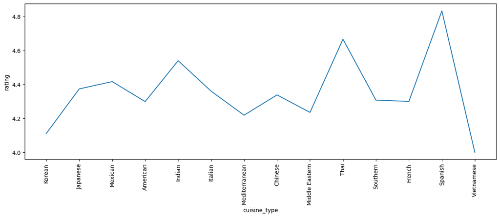

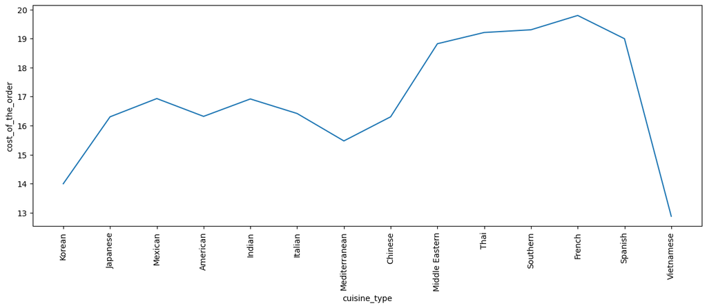

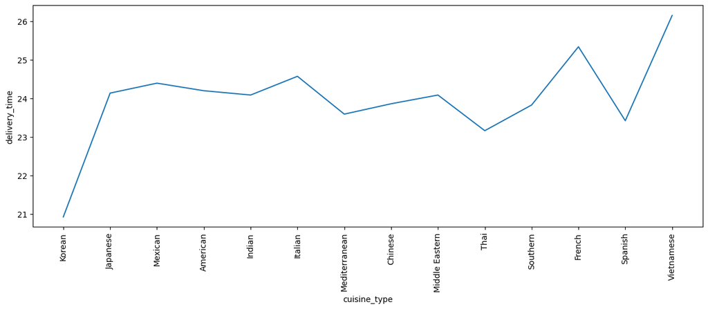

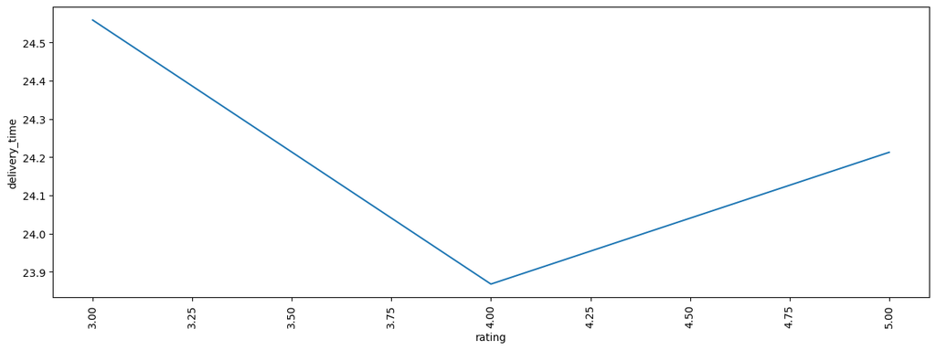

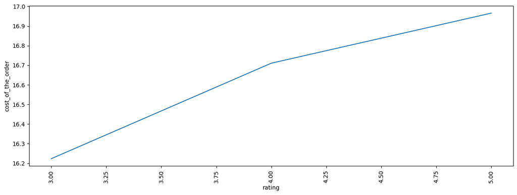

```python
plt.figure(figsize=(15,5))
sns.lineplot(data=df,y='rating',x='cuisine_type',errorbar=None)
plt.xticks(rotation=90)
plt.show()

plt.figure(figsize=(15,5))
sns.lineplot(data=df,x='cuisine_type',y='cost_of_the_order',errorbar=None)
plt.xticks(rotation=90)
plt.show()

plt.figure(figsize=(15,5))
sns.lineplot(data=df,x='cuisine_type',y='delivery_time',errorbar=None)
plt.xticks(rotation=90)
plt.show()

plt.figure(figsize=(15,5))
sns.lineplot(data=df,x='rating',y='delivery_time',errorbar=None)
plt.xticks(rotation=90)
plt.show()

plt.figure(figsize=(15,5))
sns.lineplot(data=df,x='rating',y='cost_of_the_order',errorbar=None)
plt.xticks(rotation=90)
plt.show()
```

### Recommendations:

**Observation**

**Suggestion**

- 34% of total order generated from top 5 restaurant (Shake Shack(219), The Meat Ball Shop(138), Blue Ribbon Sushi(119), Blue Ribbon Fried Chicken(96), Parm(68)) - Concentrate more on delivery time to keep good business
- 39% of the food order is not rated - provide offer or promotional scheme for customer to rate

```python
%%shell
jupyter nbconvert --to html '/content/drive/MyDrive/AIMLColab/Project FoodHub/Learner_Notebook_Full_Code.ipynb'
```

```
[NbConvertApp] Converting notebook /content/drive/MyDrive/AIMLColab/Project FoodHub/Learner_Notebook_Full_Code.ipynb to html
[NbConvertApp] Writing 1358537 bytes to /content/drive/MyDrive/AIMLColab/Project FoodHub/Learner_Notebook_Full_Code.html
```